# INFSCI 2160 Data Mining - Class 1 Sample Code

## Overview

Sample code for Week 1 will cover basic commands necessary for plotting/data visualization and data cleaning and manipulation.

For more tutorials on RStudio, see:

http://www.cyclismo.org/tutorial/R/index.html

https://bookdown.org/rdpeng/rprogdatascience/

https://bookdown.org/rdpeng/exdata/

http://www.cookbook-r.com/Graphs/

https://ismayc.github.io/rbasics-book/

http://thegrantlab.org/bio3d/79-static-content/85-why-use-r

https://www.rstudio.com/wp-content/uploads/2015/03/ggplot2-cheatsheet.pdf

https://www.burns-stat.com/documents/tutorials/why-use-the-r-language/

https://cran.r-project.org/web/packages/ggplot2/ggplot2.pdf

https://www.datacamp.com/

https://www.youtube.com/channel/UC79Gv3mYp6zKiSwYemEik9A

https://www.rdocumentation.org/

https://www.rstudio.com/wp-content/uploads/2015/02/data-wrangling-cheatsheet.pdf

For this week’s sample code, we will be using the ggplot2, ISLR, and dplyr libraries.

To install a package, you will have to use the “install.packages(”package_name“) command.

To ‘activate’ these packages and use their functionalities, run the command “library(package_name)”. We will start with ISLR.

Run the 2 following commands:

install.packages(“ISLR”)

library(ISLR)

The ISLR package comes with built in datasets. Let’s start by loading the dataset, ‘Auto’. We will call this dataset “auto_data” and save it to memory.

```r
library(ISLR)
auto_data <- Auto
```

We can check the class of the dataframe with the class() function.

Use the summary() function to get a summary of the entire dataframe.

These functions can also work on individual columns with the ‘$’ operator.

```r
class(auto_data)
```

```
## [1] "data.frame"
```

```r
summary(auto_data)
```

```
##       mpg          cylinders      displacement     horsepower
##  Min.   : 9.00   Min.   :3.000   Min.   : 68.0   Min.   : 46.0
##  1st Qu.:17.00   1st Qu.:4.000   1st Qu.:105.0   1st Qu.: 75.0
##  Median :22.75   Median :4.000   Median :151.0   Median : 93.5
##  Mean   :23.45   Mean   :5.472   Mean   :194.4   Mean   :104.5
##  3rd Qu.:29.00   3rd Qu.:8.000   3rd Qu.:275.8   3rd Qu.:126.0
##  Max.   :46.60   Max.   :8.000   Max.   :455.0   Max.   :230.0
##
##      weight      acceleration        year           origin
##  Min.   :1613   Min.   : 8.00   Min.   :70.00   Min.   :1.000
##  1st Qu.:2225   1st Qu.:13.78   1st Qu.:73.00   1st Qu.:1.000
##  Median :2804   Median :15.50   Median :76.00   Median :1.000
##  Mean   :2978   Mean   :15.54   Mean   :75.98   Mean   :1.577
##  3rd Qu.:3615   3rd Qu.:17.02   3rd Qu.:79.00   3rd Qu.:2.000
##  Max.   :5140   Max.   :24.80   Max.   :82.00   Max.   :3.000
##
##                  name
##  amc matador       :  5
##  ford pinto        :  5
##  toyota corolla    :  5
##  amc gremlin       :  4
##  amc hornet        :  4
##  chevrolet chevette:  4
##  (Other)           :365
```

```r
#Summary of 'mpg' column:
summary(auto_data$mpg)
```

```
##    Min. 1st Qu.  Median    Mean 3rd Qu.    Max.
##    9.00   17.00   22.75   23.45   29.00   46.60
```

We can also manipulate the dataset by rows or columns.

```r
#Notice that the following command saves the first 3 rows of "auto_data" into a new dataframe called "auto_data_1st_3_rows".  To save objects to memory, use the <- command.
auto_data_1st_3_rows <- auto_data[1:3,]

#The head() function will give us a view of this new dataframe
head(auto_data_1st_3_rows)
```

```
##   mpg cylinders displacement horsepower weight acceleration year origin
## 1  18         8          307        130   3504         12.0   70      1
## 2  15         8          350        165   3693         11.5   70      1
## 3  18         8          318        150   3436         11.0   70      1
##                        name
## 1 chevrolet chevelle malibu
## 2         buick skylark 320
## 3        plymouth satellite
```

```r
#To call only the first three columns of a dataframe:
auto_data_1st_3_cols <- auto_data[, 1:3]
head(auto_data_1st_3_cols)
```

```
##   mpg cylinders displacement
## 1  18         8          307
## 2  15         8          350
## 3  18         8          318
## 4  16         8          304
## 5  17         8          302
## 6  15         8          429
```

```r
#The brackets [] tell R which rows and columns to call.  It can be thought of as, [rows, columns]

#We can also call columns by their name.  Be mindful of how the quotation marks are used, as R is sensitive to this:
auto_data_mpg_and_weight_columns_only <- auto_data[, c("mpg", "weight")]
head(auto_data_mpg_and_weight_columns_only)
```

```
##   mpg weight
## 1  18   3504
## 2  15   3693
## 3  18   3436
## 4  16   3433
## 5  17   3449
## 6  15   4341
```

## Univariate Statistics

Find the mean, median, and standard deviation of the mpg column:

```r
#Mean
mean(auto_data$mpg)
```

```
## [1] 23.44592
```

```r
#Median
median(auto_data$mpg)
```

```
## [1] 22.75
```

```r
#Standard deviation
sd(auto_data$mpg)
```

```
## [1] 7.805007
```

These values can also be saved to memory as objects

```r
mean_mpg <- mean(auto_data$mpg)
mean_mpg
```

```
## [1] 23.44592
```

## Quantiles

We can also split mpg into quantiles

```r
quantile(auto_data$mpg, probs = seq(0, 1, by = 0.2))
```

```
##    0%   20%   40%   60%   80%  100%
##  9.00 16.00 20.00 25.00 30.98 46.60
```

```r
#The previous quantile() command splits the mpg column into quintiles.  We can change these splits.  For example, we can split the column into deciles:

quantile(auto_data$mpg, probs = seq(0, 1, by = 0.1))
```

```
##    0%   10%   20%   30%   40%   50%   60%   70%   80%   90%  100%
##  9.00 14.00 16.00 18.00 20.00 22.75 25.00 27.47 30.98 34.19 46.60
```

## Example 2: Analyzing College data

Let’s load a new dataset into memory and analyze it. We will use ISLR’s “College” dataset.

```r
college_data <- College
head(college_data)
```

```
##                              Private Apps Accept Enroll Top10perc
## Abilene Christian University     Yes 1660   1232    721        23
## Adelphi University               Yes 2186   1924    512        16
## Adrian College                   Yes 1428   1097    336        22
## Agnes Scott College              Yes  417    349    137        60
## Alaska Pacific University        Yes  193    146     55        16
## Albertson College                Yes  587    479    158        38
##                              Top25perc F.Undergrad P.Undergrad Outstate
## Abilene Christian University        52        2885         537     7440
## Adelphi University                  29        2683        1227    12280
## Adrian College                      50        1036          99    11250
## Agnes Scott College                 89         510          63    12960
## Alaska Pacific University           44         249         869     7560
## Albertson College                   62         678          41    13500
##                              Room.Board Books Personal PhD Terminal
## Abilene Christian University       3300   450     2200  70       78
## Adelphi University                 6450   750     1500  29       30
## Adrian College                     3750   400     1165  53       66
## Agnes Scott College                5450   450      875  92       97
## Alaska Pacific University          4120   800     1500  76       72
## Albertson College                  3335   500      675  67       73
##                              S.F.Ratio perc.alumni Expend Grad.Rate
## Abilene Christian University      18.1          12   7041        60
## Adelphi University                12.2          16  10527        56
## Adrian College                    12.9          30   8735        54
## Agnes Scott College                7.7          37  19016        59
## Alaska Pacific University         11.9           2  10922        15
## Albertson College                  9.4          11   9727        55
```

## table() function

Make a table to analyze the # of private vs. public schools

```r
#Check the class of college_data$Private
class(college_data$Private)
```

```
## [1] "factor"
```

```r
table(college_data$Private)
```

```
##
##  No Yes
## 212 565
```

## Introduction to ggplot2

For data visualization, install ggplot2 with the following command:

install.packages(“ggplot2”)

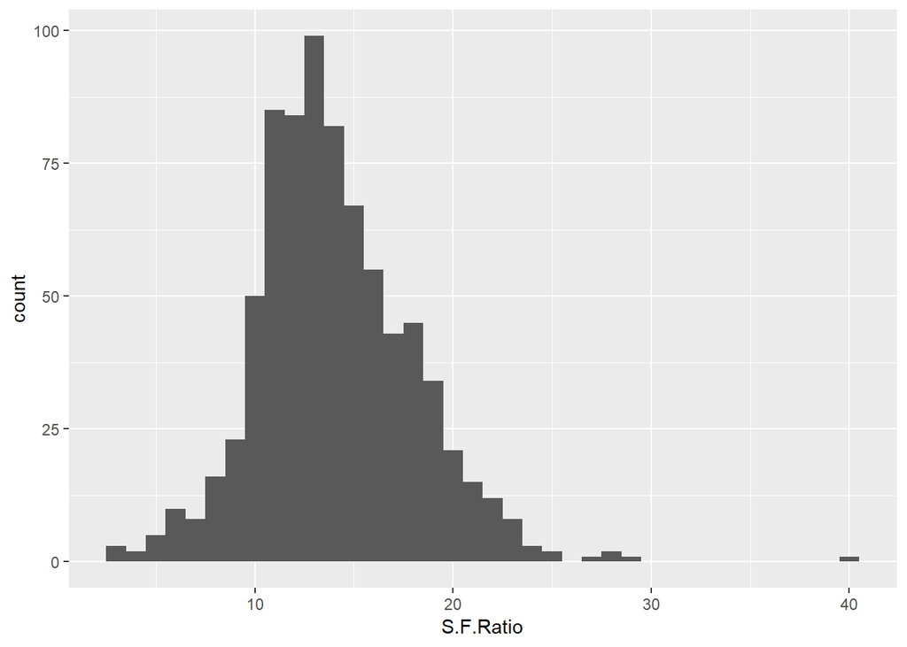

```r
#The first graph we make will be a histogram of the S.F.Ratio column
library(ggplot2)
ggplot(college_data, aes(x = S.F.Ratio)) + geom_histogram(binwidth = 1)
```

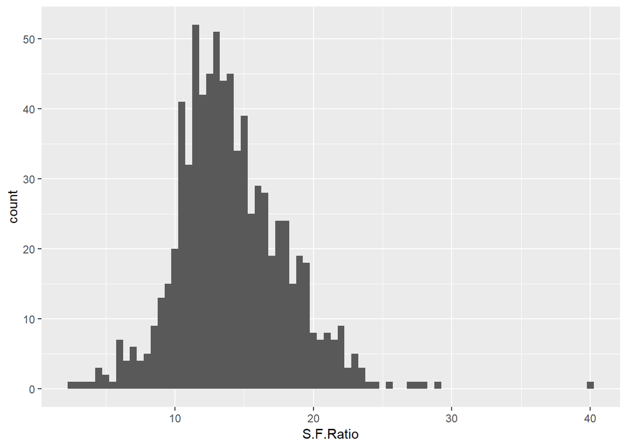

```r
#We can also assign different binwidths:
ggplot(college_data, aes(x = S.F.Ratio)) + geom_histogram(binwidth = 0.5)
```

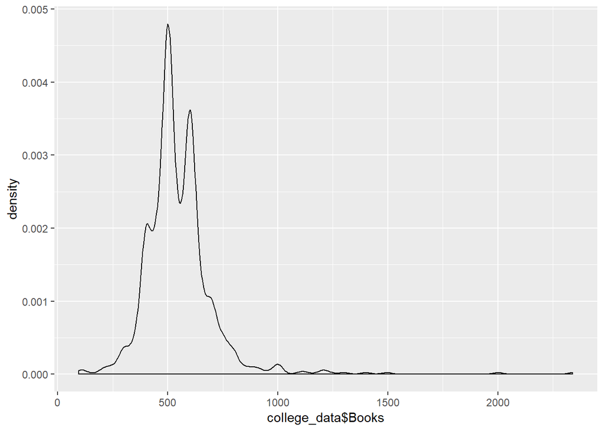

```r
#Density plot example:
ggplot(college_data, aes(x = college_data$Books)) + geom_density()
```

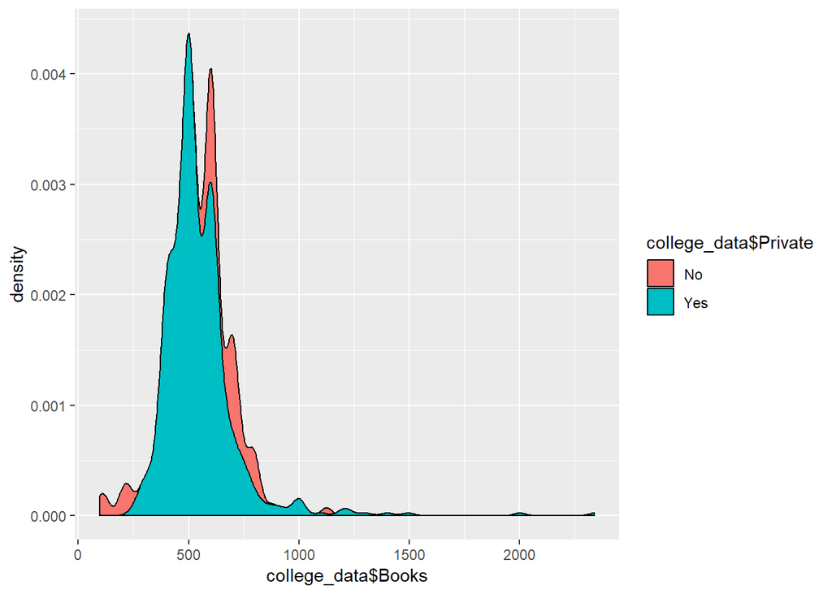

```r
#You can also make a conditional density plot.  The 1st graph will change the fill of the density by Private vs. Public schools.  The second will split them into 2 graphs:
ggplot(college_data, aes(x = college_data$Books, fill = college_data$Private)) + geom_density()
```

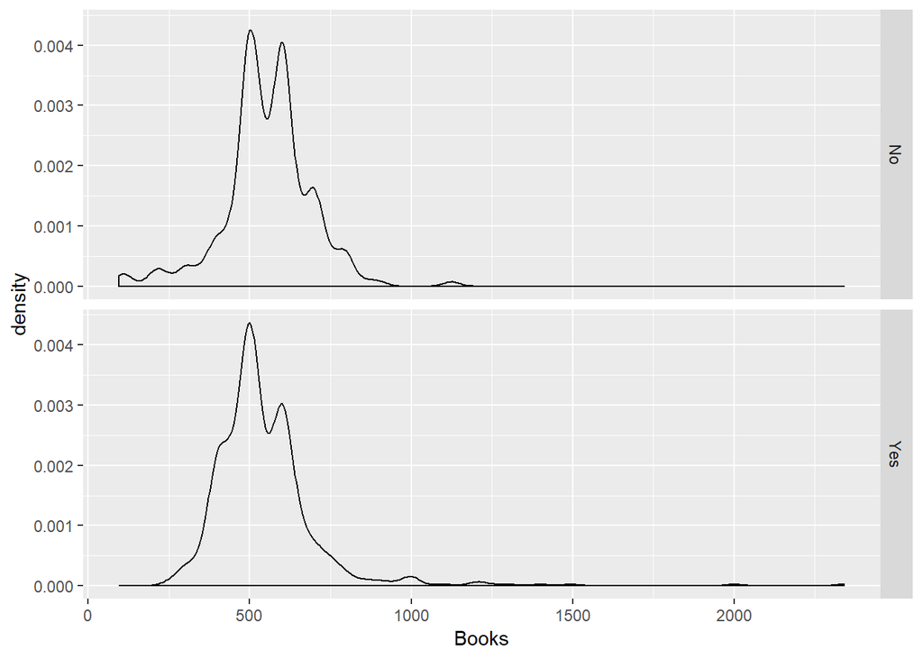

```r
ggplot(college_data, aes(x = Books)) +
  geom_density(alpha = 0.5) + facet_grid(Private ~ .)
```

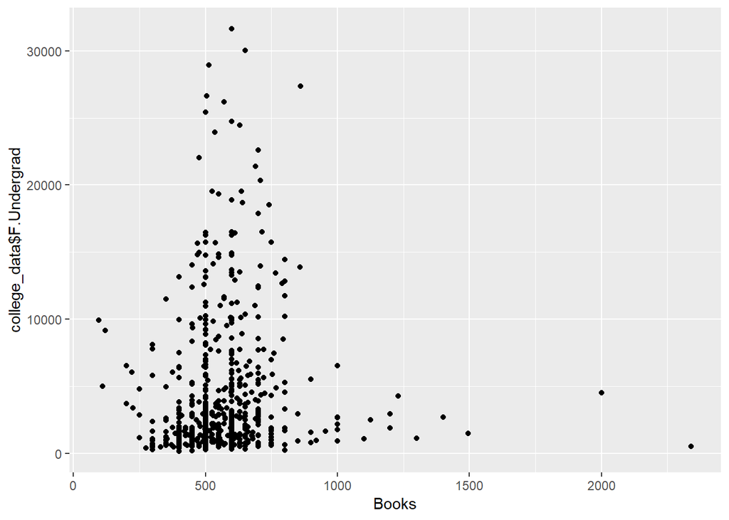

```r
#We can also make scatter plots:
ggplot(college_data, aes(x = Books, y = college_data$F.Undergrad)) + geom_point()
```

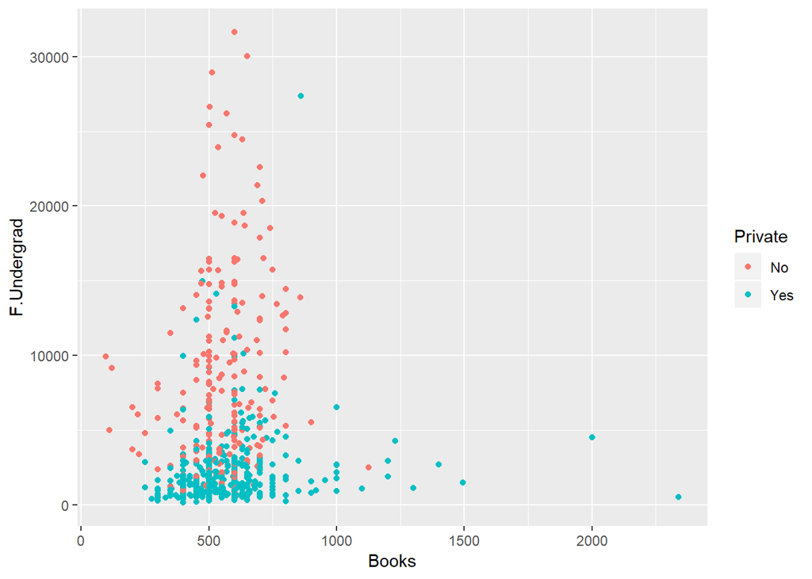

```r
#Color the plot based on private vs. public schools
ggplot(college_data, aes(x = Books, y = F.Undergrad, color = Private)) + geom_point()
```

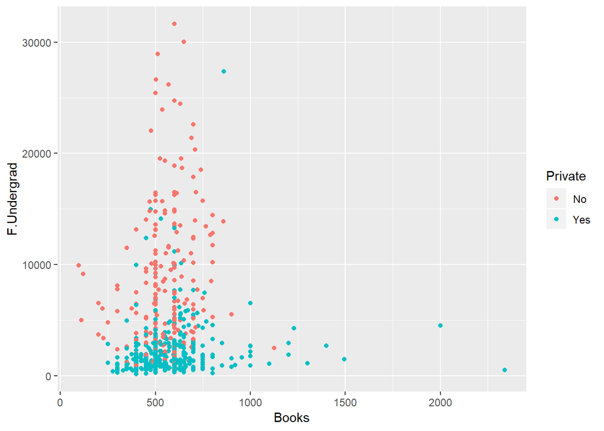

```r
#Plots can be stored and called later too:
scatter_plot_books_f_undergrad <- ggplot(college_data, aes(x = Books, y = F.Undergrad, color = Private)) + geom_point()
scatter_plot_books_f_undergrad
```

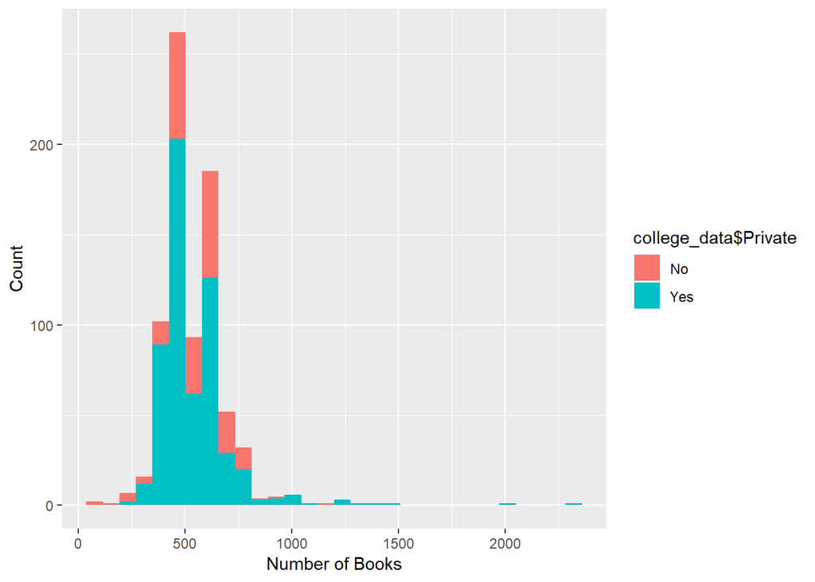

```r
#Last, we can add labels to our graphs:

ggplot(college_data, aes(x = Books, fill = college_data$Private)) + geom_histogram() + labs(x = "Number of Books", y = "Count")
```

## Introduction to dplyr

Now, we will jump into the ‘dplyr’ packages which is used for data manipulation/wrangling and cleansing.

Install the packages with the following code:

install.packages(“dplyr”)

```r
library(dplyr)
#First, we can filter out data.  Let's create two new dataframes: one for private schools and one for public schools
private_colleges <- college_data %>%
  filter(Private == "Yes")
head(private_colleges)
```

```
##   Private Apps Accept Enroll Top10perc Top25perc F.Undergrad P.Undergrad
## 1     Yes 1660   1232    721        23        52        2885         537
## 2     Yes 2186   1924    512        16        29        2683        1227
## 3     Yes 1428   1097    336        22        50        1036          99
## 4     Yes  417    349    137        60        89         510          63
## 5     Yes  193    146     55        16        44         249         869
## 6     Yes  587    479    158        38        62         678          41
##   Outstate Room.Board Books Personal PhD Terminal S.F.Ratio perc.alumni
## 1     7440       3300   450     2200  70       78      18.1          12
## 2    12280       6450   750     1500  29       30      12.2          16
## 3    11250       3750   400     1165  53       66      12.9          30
## 4    12960       5450   450      875  92       97       7.7          37
## 5     7560       4120   800     1500  76       72      11.9           2
## 6    13500       3335   500      675  67       73       9.4          11
##   Expend Grad.Rate
## 1   7041        60
## 2  10527        56
## 3   8735        54
## 4  19016        59
## 5  10922        15
## 6   9727        55
```

```r
public_colleges <- college_data %>%
  filter(Private == "No")
head(public_colleges)
```

```
##   Private  Apps Accept Enroll Top10perc Top25perc F.Undergrad P.Undergrad
## 1      No  3540   2001   1016        24        54        4190        1512
## 2      No  7313   4664   1910        20        63        9940        1035
## 3      No 12809  10308   3761        24        49       22593        7585
## 4      No  1734   1729    951        12        52        3602         939
## 5      No  7548   6791   3070        25        57       16262        1716
## 6      No  1208    877    546        12        36        3796         824
##   Outstate Room.Board Books Personal PhD Terminal S.F.Ratio perc.alumni
## 1     5130       3592   500     2000  60       62      23.1           5
## 2     6806       2540    96     2000  83       96      18.3          14
## 3     7434       4850   700     2100  88       93      18.9           5
## 4     3460       2650   450     1000  57       60      19.6           5
## 5     6300       3933   600     1908  85       91      16.7          18
## 6     4425       2700   660     1800  57       62      19.6          16
##   Expend Grad.Rate
## 1   4010        34
## 2   5854        70
## 3   4602        48
## 4   4739        48
## 5   6642        69
## 6   3752        46
```

Let’s unpack what is happening in this code. First, we are creating a new dataframe called “private_colleges” (with the <- function). Next, we are calling the dataframe “college_data”.

The ‘pipe’ operator, ‘%>%’ tells R to look at the next function. The pipe operator is a function from the dplyr package. The function we decide to use is the filter() function.

Inside of the filter function, we are citing the column we want to look at (“Private”) and to pull only records where the value = “Yes”. Notice that when we are looking for values = “Yes”, we use 2 == signs. This is true when we are filtering on any exact value with the dplyr package.

Let’s filter some other data based on columns that are continuous variables.

```r
#Filter out colleges that only accept > 1000 students
college_1000_accept <- college_data %>%
  filter(Accept >= 1000)
head(college_1000_accept)
```

```
##   Private Apps Accept Enroll Top10perc Top25perc F.Undergrad P.Undergrad
## 1     Yes 1660   1232    721        23        52        2885         537
## 2     Yes 2186   1924    512        16        29        2683        1227
## 3     Yes 1428   1097    336        22        50        1036          99
## 4     Yes 1899   1720    489        37        68        1594          32
## 5     Yes 1732   1425    472        37        75        1830         110
## 6     Yes 2652   1900    484        44        77        1707          44
##   Outstate Room.Board Books Personal PhD Terminal S.F.Ratio perc.alumni
## 1     7440       3300   450     2200  70       78      18.1          12
## 2    12280       6450   750     1500  29       30      12.2          16
## 3    11250       3750   400     1165  53       66      12.9          30
## 4    13868       4826   450      850  89      100      13.7          37
## 5    16548       5406   500      600  82       88      11.3          31
## 6    17080       4440   400      600  73       91       9.9          41
##   Expend Grad.Rate
## 1   7041        60
## 2  10527        56
## 3   8735        54
## 4  11487        73
## 5  10932        73
## 6  11711        76
```

```r
#We can also filter out colleges that accept only a certain number of students students
college_1000_exact <- college_data %>%
  filter(Accept == 1232)
summary(college_1000_exact$Accept)
```

```
##    Min. 1st Qu.  Median    Mean 3rd Qu.    Max.
##    1232    1232    1232    1232    1232    1232
```

dplyr also has a mutate function that we can use to create new variables

```r
#Make a new column called "PERCENTAGE_ACCEPTED"

college_data <- college_data %>%
  mutate(PERCENTAGE_ACCEPTED = Accept/Apps)
summary(college_data$PERCENTAGE_ACCEPTED)
```

```
##    Min. 1st Qu.  Median    Mean 3rd Qu.    Max.
##  0.1545  0.6756  0.7788  0.7469  0.8485  1.0000
```

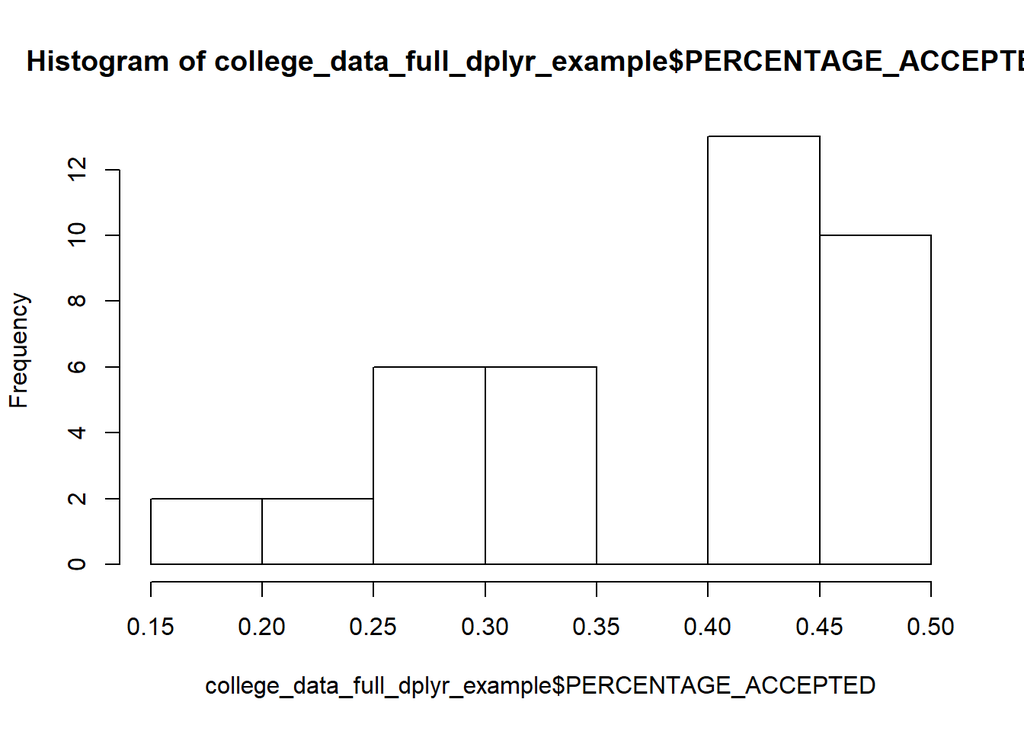

```r
#Finally, we can layer dplyr commands on top of one another.  R will perform these commands in order, and they are strung together with the pipe operator:

college_data_full_dplyr_example <- college_data %>%
  mutate(PERCENTAGE_ACCEPTED = Accept/Apps) %>%
  filter(PERCENTAGE_ACCEPTED <= 0.50) %>%
  filter(Private == "Yes")
hist(college_data_full_dplyr_example$PERCENTAGE_ACCEPTED)
```

## rbind() function: Appending Data

Sometimes, we may want to append two dataframes together. For example, assume we were given the public and private school datasets separately (they are currently stored in memory as ‘private_colleges’ and ‘public_colleges’). If we wanted to combine these datasets into one dataframe, we could use the rbind command:

```r
college_data_full <- rbind(private_colleges, public_colleges)
head(college_data_full)
```

```
##   Private Apps Accept Enroll Top10perc Top25perc F.Undergrad P.Undergrad
## 1     Yes 1660   1232    721        23        52        2885         537
## 2     Yes 2186   1924    512        16        29        2683        1227
## 3     Yes 1428   1097    336        22        50        1036          99
## 4     Yes  417    349    137        60        89         510          63
## 5     Yes  193    146     55        16        44         249         869
## 6     Yes  587    479    158        38        62         678          41
##   Outstate Room.Board Books Personal PhD Terminal S.F.Ratio perc.alumni
## 1     7440       3300   450     2200  70       78      18.1          12
## 2    12280       6450   750     1500  29       30      12.2          16
## 3    11250       3750   400     1165  53       66      12.9          30
## 4    12960       5450   450      875  92       97       7.7          37
## 5     7560       4120   800     1500  76       72      11.9           2
## 6    13500       3335   500      675  67       73       9.4          11
##   Expend Grad.Rate
## 1   7041        60
## 2  10527        56
## 3   8735        54
## 4  19016        59
## 5  10922        15
## 6   9727        55
```

## Merging Data

In this example, we will create 2 mock datasets and store them in memory as dataframes. We want to pull the data together into one dataframe for analysis.

```r
#Create a mock dataframe called "employees"
employees <- data.frame("EMPLOYEE_NAME" = c("Alice", "Bob", "Carla", "Daniel", "Evelyn", "Ferdinand"),
                        "DEPT_NAME" = c("A", "B", "A", "C", "B", "D"),
                        "SALARY" = c(1000, 2000, 3000, 1500, 4000, 10000),
                        stringsAsFactors = FALSE)
summary(employees)
```

```
##  EMPLOYEE_NAME       DEPT_NAME             SALARY
##  Length:6           Length:6           Min.   : 1000
##  Class :character   Class :character   1st Qu.: 1625
##  Mode  :character   Mode  :character   Median : 2500
##                                        Mean   : 3583
##                                        3rd Qu.: 3750
##                                        Max.   :10000
```

```r
departments <- data.frame("DEPT_NAME" = c("A", "B", "C", "D"),
                          "MANAGER" = c("1", "2", "3", NA),
                          stringsAsFactors = FALSE)
summary(departments)
```

```
##   DEPT_NAME           MANAGER
##  Length:4           Length:4
##  Class :character   Class :character
##  Mode  :character   Mode  :character
```

```r
#We can also find how many nulls are in the datasets:
sum(is.na(departments))
```

```
## [1] 1
```

```r
sum(is.na(employees))
```

```
## [1] 0
```

```r
#Or, we can find how many nulls are in a specific column:
sum(is.na(departments$MANAGER))
```

```
## [1] 1
```

We now have 2 dataframes, one with employee data and one with apartment data. Suppose we want all of the department names that the employees work for. We can do an INNER JOIN to combine the DEPT_NAME column onto the employees table with the following code:

merge(df1, df2, by = “column_name”)

For more on joins see:

https://stackoverflow.com/questions/1299871/how-to-join-merge-data-frames-inner-outer-left-right

https://rstudio-pubs-static.s3.amazonaws.com/52230_5ae0d25125b544caab32f75f0360e775.html

```r
employees_w_dept_info <- merge(employees, departments, by = "DEPT_NAME")
```

## Changing data classes

Last, suppose we want to change the class of the data. For example, suppose we want to change DEPT_NAME from a character to a factor variable:

```r
class(departments$DEPT_NAME)
```

```
## [1] "character"
```

```r
departments$DEPT_NAME <- as.factor(departments$DEPT_NAME)
class(departments$DEPT_NAME)
```

```
## [1] "factor"
```

```r
summary(departments$DEPT_NAME)
```

```
## A B C D
## 1 1 1 1
```

```r
head(departments$DEPT_NAME)
```

```
## [1] A B C D
## Levels: A B C D
```

We can also change departments$DEPT_NAME to a numeric variable:

```r
class(departments$DEPT_NAME)
```

```
## [1] "factor"
```

```r
departments$DEPT_NAME <- as.numeric(departments$DEPT_NAME)
class(departments$DEPT_NAME)
```

```
## [1] "numeric"
```

```r
summary(departments$DEPT_NAME)
```

```
##    Min. 1st Qu.  Median    Mean 3rd Qu.    Max.
##    1.00    1.75    2.50    2.50    3.25    4.00
```

```r
head(departments$DEPT_NAME)
```

```
## [1] 1 2 3 4
```